# ¶ **Using `afrilearndata` in learning Spatial Analysis with R** ¶

¶ Wyclife Agumba Oluoch (wyclifeoluoch@gmail.com) ¶

¶ 2022-11-05 20:25:55 ¶

# Introduction

`afrilearndata` library has useful data that can be used to learn Spatial Analysis in `R` within the African context. Having vector (with attribute data) and raster (with pixel values), the possibilities of analytic approaches are unlimited. I will barely **glimpse** tip of the iceberg.

You can find the rmd file in my [GitHub](https://github.com/Wycology/afrilearn_data/blob/main/afrilearn_data.Rmd) account and more about the package [here](https://github.com/afrimapr/afrilearndata).

## Simple mapping of the countries

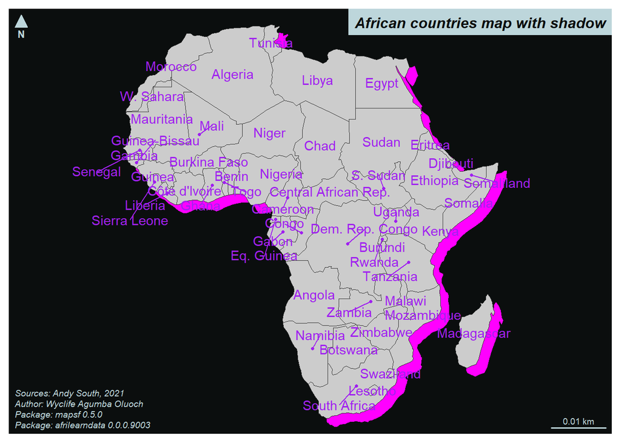

```r
mf_init(africountries, expandBB = rep(0, 4), theme = 'iceberg')
mf_shadow(africountries, col = 'magenta', cex = 2, add = TRUE) # just for aesthetic
mf_layout(title = 'African countries map with shadow',
          credits = paste0('Sources: Andy South, 2021\nAuthor: Wyclife Agumba Oluoch\n',
          'Package: mapsf ',
          packageVersion('mapsf'), '\nPackage: afrilearndata ',
          packageVersion('afrilearndata')))
mf_map(africountries, add = TRUE)
mf_label(africountries, var = "name", col = "purple", cex = 0.9, font = 250, bg = "white", r = 0.4, overlap = FALSE, lines = TRUE)
```

## Mapping of population field as proprotional circles

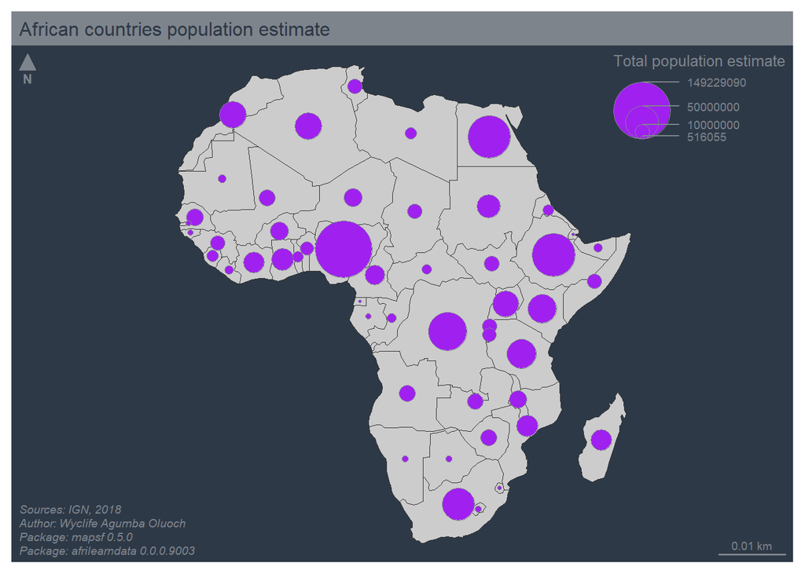

```r
mf_init(africountries, expandBB = rep(0, 4), theme = 'dark')
mf_layout(title = 'African countries population estimate',
          credits = paste0('Sources: IGN, 2018\nAuthor: Wyclife Agumba Oluoch\n',
          'Package: mapsf ',
          packageVersion('mapsf'), '\nPackage: afrilearndata ',
          packageVersion('afrilearndata')))
mf_map(africountries, add = TRUE)
mf_map(x = africountries, var = 'pop_est', type = 'prop', inches = 0.25,
       col = 'purple', leg_pos = 'topright', leg_title = 'Total population estimate'
)
```

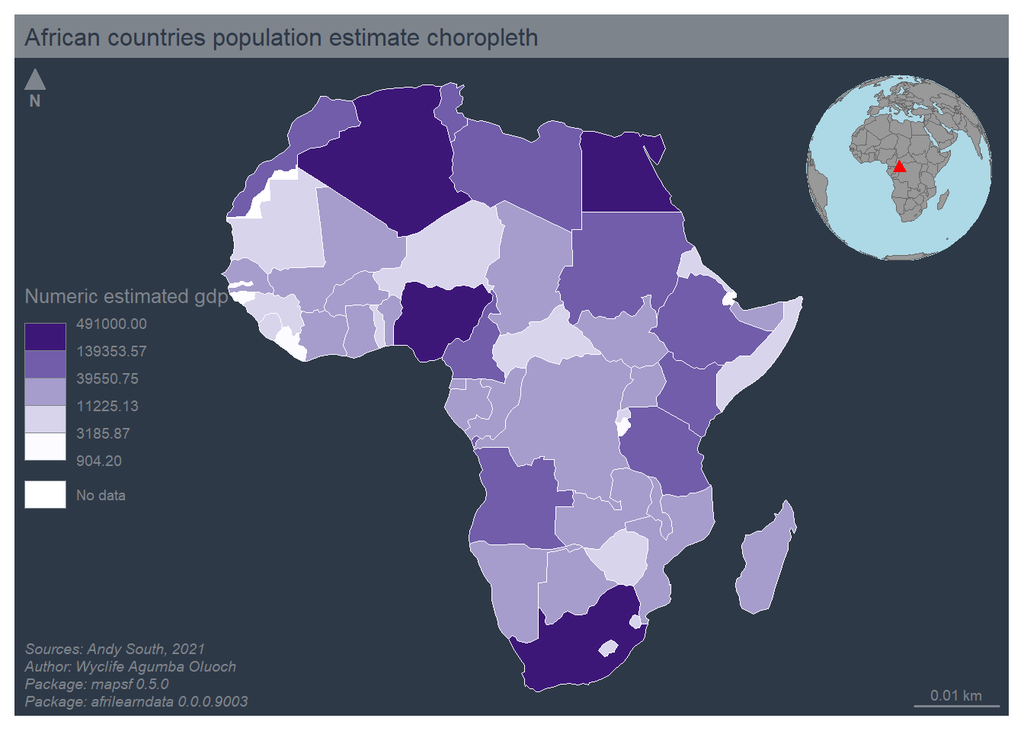

```r
mf_init(africountries, expandBB = rep(0, 4), theme = 'dark')
mf_layout(title = 'African countries population estimate choropleth',
          credits = paste0('Sources: Andy South, 2021\nAuthor: Wyclife Agumba Oluoch\n', 'Package: mapsf ',
                           packageVersion('mapsf'), '\nPackage: afrilearndata ',
                           packageVersion('afrilearndata')))
mf_map(x = africountries, var = "gdp_md_est", type = "choro", breaks = "geom",
       nbreaks = 5, pal = "Purples", border = "white", lwd = 0.5, leg_pos = "left",
       leg_title = "Numeric estimated gdp", add = TRUE)
mf_inset_on(x = 'worldmap', pos = 'topright')
mf_worldmap(africountries, col = "red")
mf_inset_off()
```

# Extracting population raster data for each country

```r
afripop2020_extract <- africountries %>%
  mutate(pop_2020 = raster::extract(afripop2020, africountries, fun = mean, na.rm = TRUE))
```

So cool that we can extract mean values and mutate in the countries data as a new column to be used in subsequent mapping.

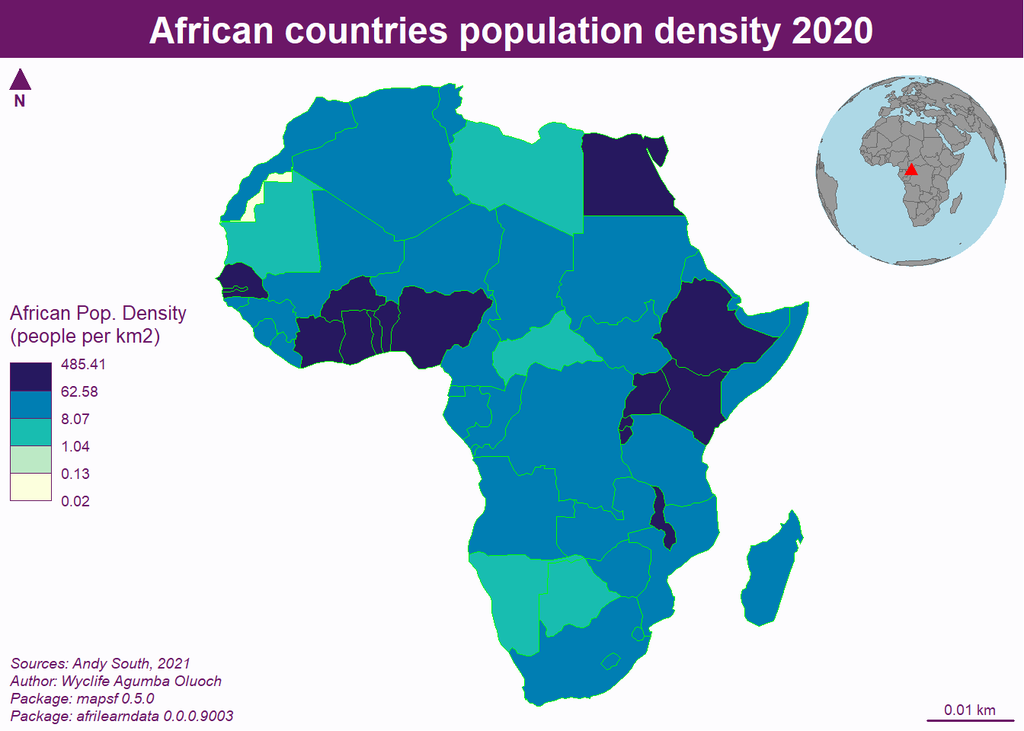

```r
mf_init(afripop2020_extract, expandBB = rep(0, 4), theme = 'candy')
mf_layout(title = 'African countries population density 2020',
          credits = paste0('Sources: Andy South, 2021\nAuthor: Wyclife Agumba Oluoch\n', 'Package: mapsf ',
                           packageVersion('mapsf'), '\nPackage: afrilearndata ',
                           packageVersion('afrilearndata')))
mf_map(x = afripop2020_extract, var = "pop_2020", type = "choro", breaks = "geom", nbreaks = 5,
  pal = "YlGnBu", border = "green", lwd = 0.5, leg_pos = "left",
  leg_title = "African Pop. Density\n(people per km2)", add = TRUE)
mf_inset_on(x = 'worldmap', pos = 'topright')
mf_worldmap(afripop2020_extract, col = "red")
mf_inset_off()
```

# Selective mapping

Here I map only countries whose pop_2020 values are above 100.

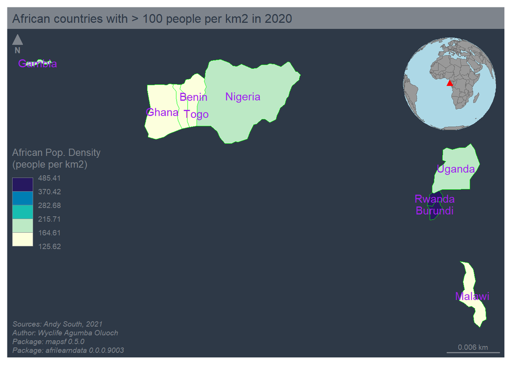

```r
afri_pop_2020_100 <- afripop2020_extract %>% filter(pop_2020 > 100)
mf_init(afri_pop_2020_100, expandBB = rep(0, 4), theme = 'dark')
mf_layout(title = 'African countries with > 100 people per km2 in 2020',
          credits = paste0('Sources: Andy South, 2021\nAuthor: Wyclife Agumba Oluoch\n', 'Package: mapsf ',
                           packageVersion('mapsf'), '\nPackage: afrilearndata ',
                           packageVersion('afrilearndata')))
mf_map(x = afri_pop_2020_100, var = "pop_2020", type = "choro", breaks = "geom", nbreaks = 5,
  pal = "YlGnBu", border = "green", lwd = 0.5, leg_pos = "left",
  leg_title = "African Pop. Density\n(people per km2)", add = TRUE)
mf_label(x = afri_pop_2020_100, var = "name", col = "purple", cex = 0.9, font = 250, bg = "white", r = 0.4, overlap = FALSE, lines = FALSE)
mf_inset_on(x = 'worldmap', pos = 'topright')
mf_worldmap(afri_pop_2020_100, col = "red")
mf_inset_off()
```

Here I map countries whose population density values by 2020 fell below 20 people per square km.

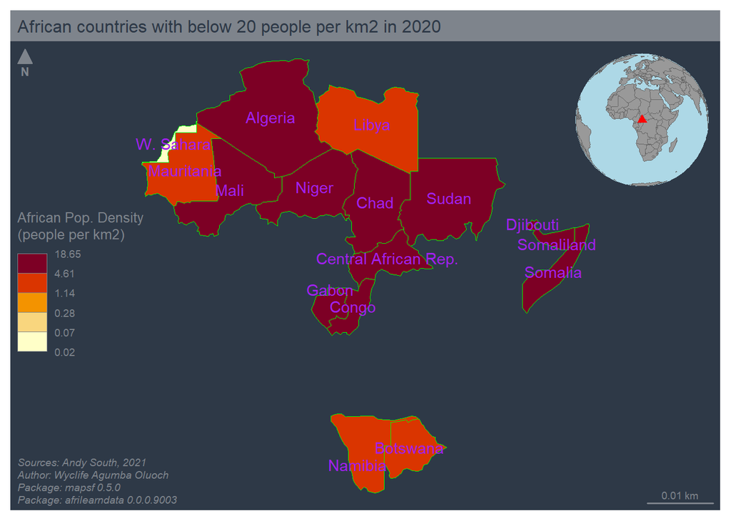

```r
afri_pop_2020_below_20 <- afripop2020_extract %>% filter(pop_2020 < 20)
mf_init(afri_pop_2020_below_20, expandBB = rep(0, 4), theme = 'dark')
mf_layout(title = 'African countries with below 20 people per km2 in 2020',
          credits = paste0('Sources: Andy South, 2021\nAuthor: Wyclife Agumba Oluoch\n', 'Package: mapsf ',
                           packageVersion('mapsf'), '\nPackage: afrilearndata ',
                           packageVersion('afrilearndata')))
mf_map(x = afri_pop_2020_below_20, var = "pop_2020", type = "choro", breaks = "geom", nbreaks = 5,
  pal = "YlOrRd", border = "green", lwd = 0.5, leg_pos = "left",
  leg_title = "African Pop. Density\n(people per km2)", add = TRUE)
mf_label(x = afri_pop_2020_below_20, var = "name", col = "purple", cex = 0.9, font = 250, bg = "white", r = 0.4, overlap = FALSE, lines = FALSE)
mf_inset_on(x = 'worldmap', pos = 'topright')
mf_worldmap(afri_pop_2020_below_20, col = "red")
mf_inset_off()
```

Here is map of the country with maximum population density by 2020.

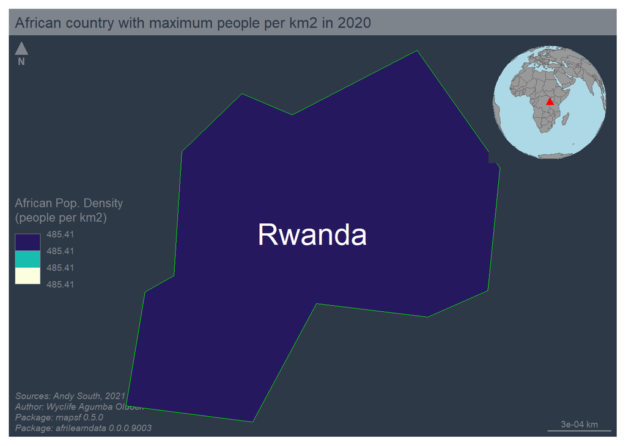

```r
afri_pop_2020_max <- afripop2020_extract %>% filter(pop_2020 == max(pop_2020, na.rm = TRUE))
mf_init(afri_pop_2020_max, expandBB = rep(0, 4), theme = 'dark')
mf_layout(title = 'African country with maximum people per km2 in 2020',
          credits = paste0('Sources: Andy South, 2021\nAuthor: Wyclife Agumba Oluoch\n', 'Package: mapsf ',
                           packageVersion('mapsf'), '\nPackage: afrilearndata ',
                           packageVersion('afrilearndata')))
mf_map(x = afri_pop_2020_max, var = "pop_2020", type = "choro", breaks = "geom", nbreaks = 1,
  pal = "YlGnBu", border = "green", lwd = 0.5, leg_pos = "left",
  leg_title = "African Pop. Density\n(people per km2)", add = TRUE)
mf_label(x = afri_pop_2020_max, var = "name", col = "white", cex = 2, font = 250, bg = "white", r = 0.4, overlap = FALSE, lines = FALSE)
mf_inset_on(x = 'worldmap', pos = 'topright')
mf_worldmap(afri_pop_2020_max, col = "red")
mf_inset_off()
```

Here is map of the country with least/minimum population density by 2020

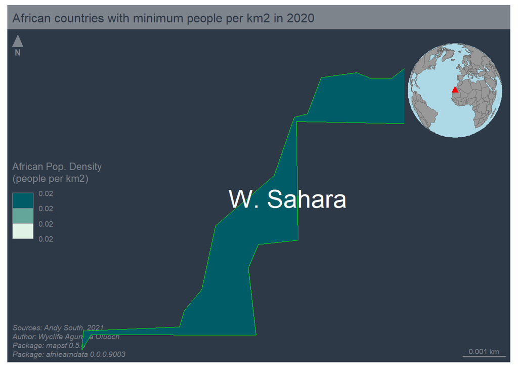

```r
afri_pop_2020_min <- afripop2020_extract %>% filter(pop_2020 == min(pop_2020, na.rm = TRUE))
mf_init(afri_pop_2020_min, expandBB = rep(0, 4), theme = 'dark')
mf_layout(title = 'African countries with minimum people per km2 in 2020',
          credits = paste0('Sources: Andy South, 2021\nAuthor: Wyclife Agumba Oluoch\n', 'Package: mapsf ',
                           packageVersion('mapsf'), '\nPackage: afrilearndata ',
                           packageVersion('afrilearndata')))
mf_map(x = afri_pop_2020_min, var = "pop_2020", type = "choro", breaks = "geom", nbreaks = 1,
  col = "cyan", border = "green", lwd = 0.5, leg_pos = "left",
  leg_title = "African Pop. Density\n(people per km2)", add = TRUE)
mf_label(x = afri_pop_2020_min, var = "name", col = "white", cex = 2, font = 250, bg = "white", r = 0.4, overlap = FALSE, lines = FALSE)
mf_inset_on(x = 'worldmap', pos = 'topright')
mf_worldmap(afri_pop_2020_min, col = "red")
mf_inset_off()
```

```r
land_cover <- rast(system.file("extdata","afrilandcover.grd", package="afrilearndata", mustWork = TRUE))
```

```python
# reticulate::repl_python()
import pandas as pd
sample_data = pd.read_csv("D:/comp.csv")
sample_data.head()
```

```
##                                  threat  nas_score  ata_score  lop_score
## 0                        Climate change        117        111         57
## 1                      Invasive species         88        104         89
## 2              Overstocking/overgrazing         65         93        102
## 3   Selective harvesting/Overharvesting         61         76        110
## 4  Fuelwood collection/charcoal burning         43         69         97
```

```r
# mf_init(land_cover, expandBB = rep(0, 4), theme = 'dark')
# mf_raster(land_cover, add = TRUE, bgalpha = 0.1)
```

The raster for the whole continent can be cropped and masked for a specific country extent. Here I do one for Kenya.

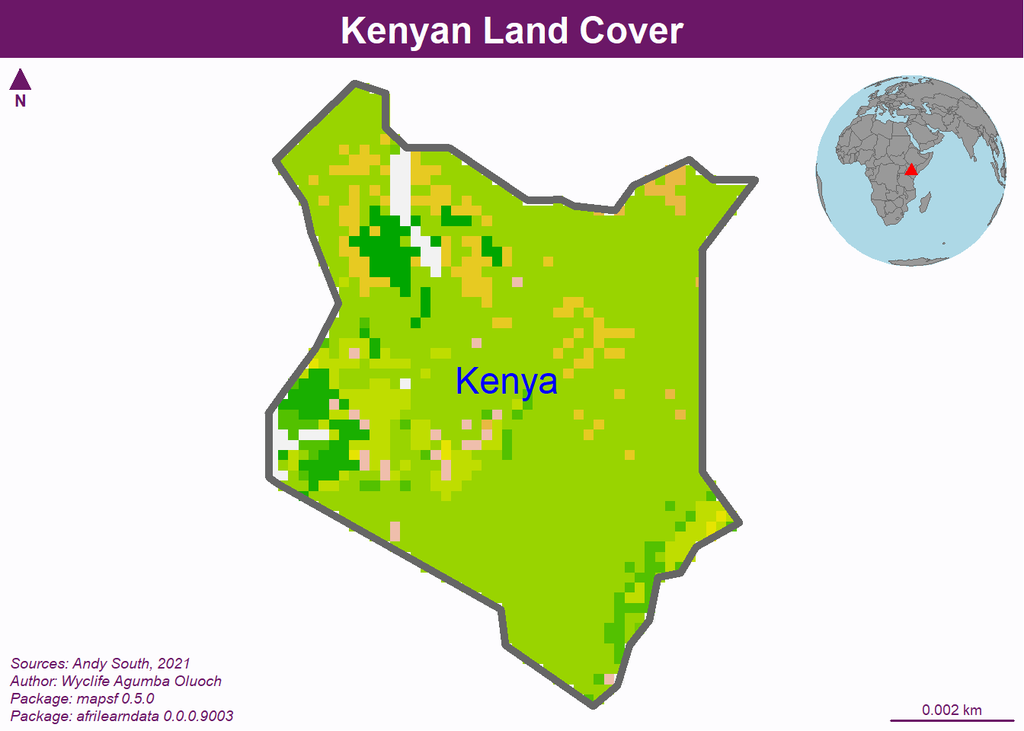

```r
kenya_sf <- africountries[africountries$name == 'Kenya',]
kenya_sp <- sf::as_Spatial(kenya_sf)

kenya_mask <- raster::mask(raster::crop(raster::raster(land_cover), kenya_sp), kenya_sp)

mf_init(kenya_sf, theme = "candy")
mf_raster(rast(kenya_mask), add = TRUE)
mf_map(kenya_sf, add = TRUE, col = 'transparent', lwd = 5, border = 'grey40',
              graticule  = sf::st_crs(4326))
mf_layout(title = 'Kenyan Land Cover',
          credits = paste0('Sources: Andy South, 2021\nAuthor: Wyclife Agumba Oluoch\n', 'Package: mapsf ',
                           packageVersion('mapsf'), '\nPackage: afrilearndata ',
                           packageVersion('afrilearndata')))
mf_label(x = kenya_sf, var = "name", col = "blue", cex = 1.5,
         font = 250, bg = "white", r = 0.4)
mf_inset_on(x = 'worldmap', pos = 'topright')
mf_worldmap(kenya_sf, col = "red")
mf_inset_off()
```

```r
# kenya_land_cover <- raster::crop(land_cover, africountries[africountries$name == 'Kenya',])
# kenya_mask <- raster::mask(kenya_land_cover, vect(africountries[africountries$name == 'Kenya',]))
# kenya_sf <- africountries[africountries$name == 'Kenya',]
# mf_init(kenya_mask, expandBB = rep(0, 4), theme = 'dark')
# mf_raster(kenya_mask, add = TRUE, bgalpha = 0.1)
# mf_layout(title = 'Kenyan Land Cover',
#           credits = paste0('Sources: Andy South, 2021\nAuthor: Wyclife Agumba Oluoch\n', 'Package: mapsf ',
#                            packageVersion('mapsf'), '\nPackage: afrilearndata ',
#                            packageVersion('afrilearndata')))
# mf_map(x = kenya_sf, add = TRUE, col = 'transparent', lwd = 15, border = 'purple')
# mf_label(x = kenya_sf, var = "name", col = "blue", cex = 2, font = 250, bg = "white", r = 0.4, overlap = FALSE, lines = FALSE)
# mf_inset_on(x = 'worldmap', pos = 'topright')
# mf_worldmap(kenya_sf, col = "red")
# mf_inset_off()
```

> As I said earlier, this is a mere glimpse of the iceberg tip. The scale bars in the maps could be misleading as they are in degrees and not kms. In other words, I should have projected the data as follows:

```r
#kenya_mask_reproj <- terra::project(kenya_mask, "EPSG:21096")
# kenya_sf_reproj <- st_transform(kenya_sf, "EPSG:21096")
# mf_init(kenya_mask_reproj, expandBB = rep(0, 4), theme = 'dark')
# mf_raster(kenya_mask_reproj, add = TRUE, bgalpha = 0.1)
# mf_layout(title = 'Kenyan Land Cover',
#           credits = paste0('Sources: Andy South, 2021\nAuthor: Wyclife Agumba Oluoch\n', 'Package: mapsf ',
#                            packageVersion('mapsf'), '\nPackage: afrilearndata ',
#                            packageVersion('afrilearndata')))
# mf_map(x = kenya_sf_reproj, add = TRUE, col = 'transparent', lwd = 15, border = 'purple')
# mf_label(x = kenya_sf_reproj, var = "name", col = "blue", cex = 2, font = 250, bg = "white", r = 0.4, overlap = FALSE, lines = FALSE)
# mf_inset_on(x = 'worldmap', pos = 'topright')
# mf_worldmap(kenya_sf_reproj, col = "red")
# mf_inset_off()
```